# Lab-5

Karthikcharan Suresh

11/13/2019

#### 1

```r
data<-read.table('diabetes.txt',header=TRUE)
head(data)
```

```
##     id chol stab.glu hdl ratio glyhb   location age gender height weight
## 1 1000  203       82  56   3.6  4.31 Buckingham  46 female     62    121
## 2 1001  165       97  24   6.9  4.44 Buckingham  29 female     64    218
## 3 1002  228       92  37   6.2  4.64 Buckingham  58 female     61    256
## 4 1003   78       93  12   6.5  4.63 Buckingham  67   male     67    119
## 5 1005  249       90  28   8.9  7.72 Buckingham  64   male     68    183
## 6 1008  248       94  69   3.6  4.81 Buckingham  34   male     71    190
##    frame bp.1s bp.1d bp.2s bp.2d waist hip time.ppn
## 1 medium   118    59    NA    NA    29  38      720
## 2  large   112    68    NA    NA    46  48      360
## 3  large   190    92   185    92    49  57      180
## 4  large   110    50    NA    NA    33  38      480
## 5 medium   138    80    NA    NA    44  41      300
## 6  large   132    86    NA    NA    36  42      195
```

#### 2

```r
data[data==""]<-NA
data<-droplevels(data, "")
head(data)
```

```
##     id chol stab.glu hdl ratio glyhb   location age gender height weight
## 1 1000  203       82  56   3.6  4.31 Buckingham  46 female     62    121
## 2 1001  165       97  24   6.9  4.44 Buckingham  29 female     64    218
## 3 1002  228       92  37   6.2  4.64 Buckingham  58 female     61    256
## 4 1003   78       93  12   6.5  4.63 Buckingham  67   male     67    119
## 5 1005  249       90  28   8.9  7.72 Buckingham  64   male     68    183
## 6 1008  248       94  69   3.6  4.81 Buckingham  34   male     71    190
##    frame bp.1s bp.1d bp.2s bp.2d waist hip time.ppn
## 1 medium   118    59    NA    NA    29  38      720
## 2  large   112    68    NA    NA    46  48      360
## 3  large   190    92   185    92    49  57      180
## 4  large   110    50    NA    NA    33  38      480
## 5 medium   138    80    NA    NA    44  41      300
## 6  large   132    86    NA    NA    36  42      195
```

#### 3

```r
vars<-names(data) %in% c("id", "bp.2s", "bp.2d")
diabetes_reduced<-data[!vars]
head(diabetes_reduced)
```

```
##   chol stab.glu hdl ratio glyhb   location age gender height weight  frame
## 1  203       82  56   3.6  4.31 Buckingham  46 female     62    121 medium
## 2  165       97  24   6.9  4.44 Buckingham  29 female     64    218  large
## 3  228       92  37   6.2  4.64 Buckingham  58 female     61    256  large
## 4   78       93  12   6.5  4.63 Buckingham  67   male     67    119  large
## 5  249       90  28   8.9  7.72 Buckingham  64   male     68    183 medium
## 6  248       94  69   3.6  4.81 Buckingham  34   male     71    190  large
##   bp.1s bp.1d waist hip time.ppn
## 1   118    59    29  38      720
## 2   112    68    46  48      360
## 3   190    92    49  57      180
## 4   110    50    33  38      480
## 5   138    80    44  41      300
## 6   132    86    36  42      195
```

##### 4

```r
index.na=apply(is.na(diabetes_reduced), 1, any)
diabetes_clean<-diabetes_reduced[!index.na,]
```

#### 5

```r
dim(diabetes_clean)
```

```
## [1] 366  16
```

there are 366 rows and 16 columns from looking at the dimensions of the dataset

### Exploring and transforming data

#### 6

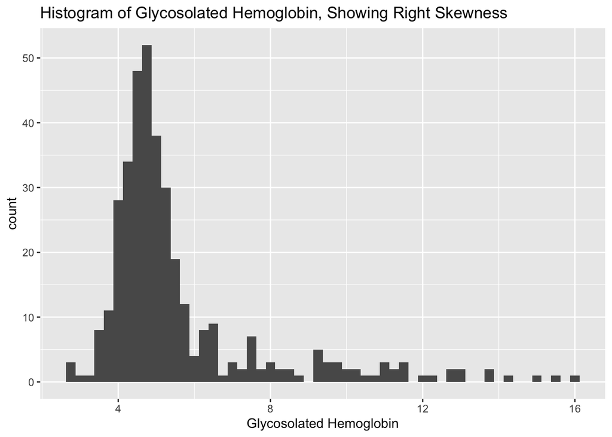

```r
library(ggplot2)
ggplot(data = diabetes_clean ,aes(x = glyhb))+ geom_histogram(binwidth = .25) +
          ggtitle("Histogram of Glycosolated Hemoglobin, Showing Right Skewness") +
          xlab("Glycosolated Hemoglobin")
```

#We can create a log of `glyhb` to fix the righ skewness, this will fix the skewness but the histogram is hard to interpret. So we can transform the variable to visualize better.

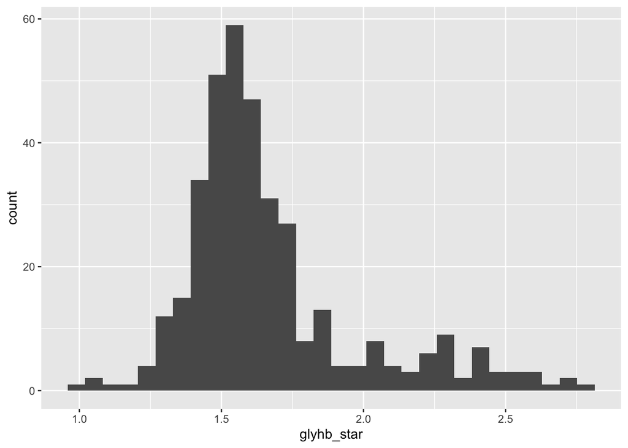

```r
diabetes_clean$glyhb_star = log(diabetes_clean$glyhb)
library(ggplot2)
ggplot(diabetes_clean, aes(glyhb_star))+geom_histogram(bins=30)
```

```r
library(dplyr)
diabetes_clean %>% group_by(weight) %>% summarise(mean.glyhb = mean(glyhb_star))
```

```
## # A tibble: 137 x 2
##    weight mean.glyhb
##     <int>      <dbl>
##  1     99       1.46
##  2    102       1.49
##  3    105       1.46
##  4    109       1.54
##  5    110       1.58
##  6    113       1.53
##  7    114       1.35
##  8    115       1.34
##  9    118       1.40
## 10    119       1.47
## # … with 127 more rows
```

```r
diabetes_clean %>% group_by(age) %>% summarise(mean.glyhb = mean(glyhb_star))
```

```
## # A tibble: 67 x 2
##      age mean.glyhb
##    <int>      <dbl>
##  1    19       1.51
##  2    20       1.51
##  3    21       1.47
##  4    22       1.39
##  5    23       1.53
##  6    24       1.53
##  7    25       1.58
##  8    26       1.61
##  9    27       1.51
## 10    28       1.45
## # … with 57 more rows
```

```r
diabetes_clean %>% group_by(gender) %>% summarise(mean.glyhb = mean(glyhb_star))
```

```
## # A tibble: 2 x 2
##   gender mean.glyhb
##   <fct>       <dbl>
## 1 female       1.65
## 2 male         1.69
```

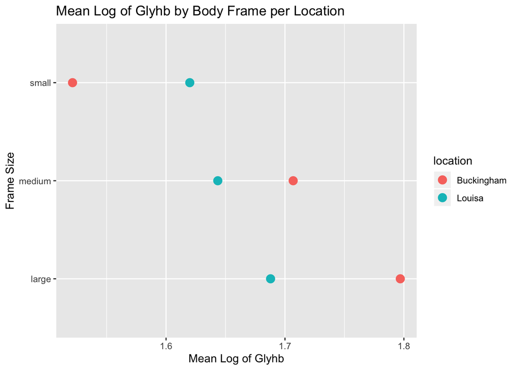

```r
diabetes_clean %>% group_by(frame,location) %>% summarise (mean.glyhb_star= mean(glyhb_star)) %>%
  ggplot(aes(x = frame, y = mean.glyhb_star, color=`location`))+
  geom_point(size=3.5)+
  coord_flip()+
  labs(title = 'Mean Log of Glyhb by Body Frame per Location', y = 'Mean Log of Glyhb', x='Frame Size')
```

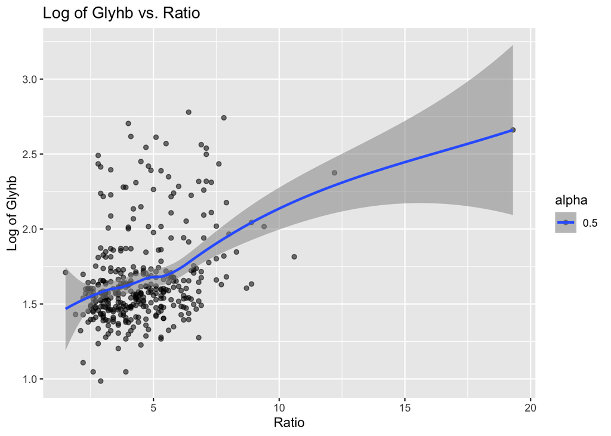

```r
ggplot(diabetes_clean,aes(y=glyhb_star,x=ratio,alpha=0.5)) + geom_point() +  geom_smooth()+labs(title = 'Log of Glyhb vs. Ratio',
                                                                                 x='Ratio',
                                                                                 y='Log of Glyhb')
```

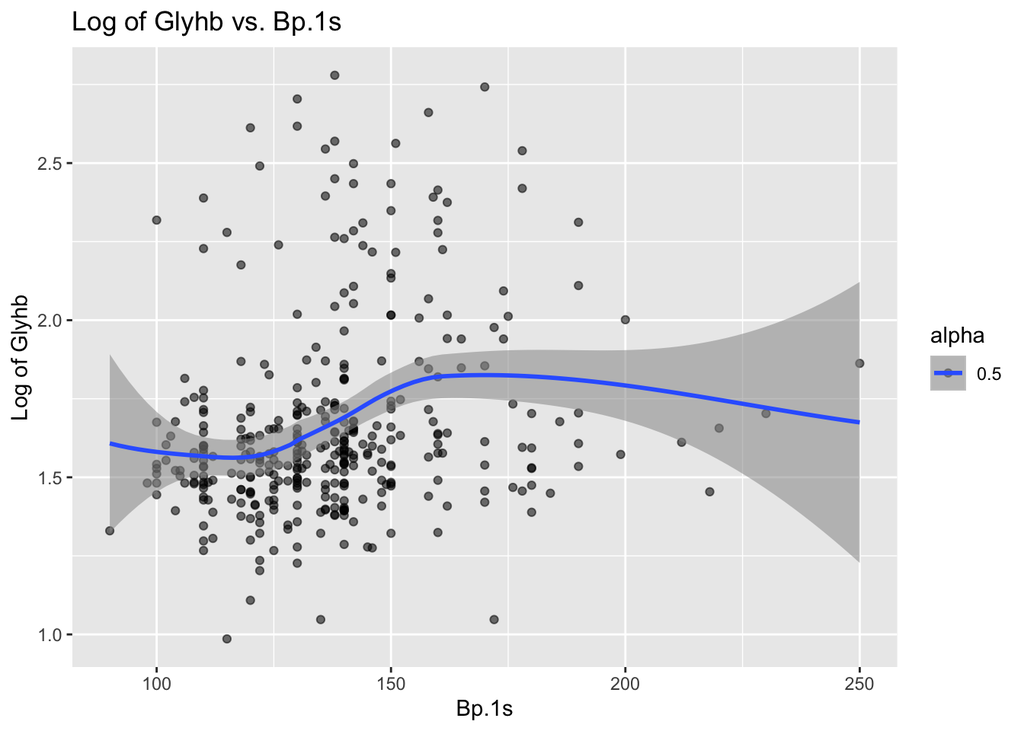

```r
ggplot(diabetes_clean,aes(y=glyhb_star,x=bp.1s,alpha=0.5)) + geom_point() + geom_smooth()+ labs(title = 'Log of Glyhb vs. Bp.1s',
                                                                                 x='Bp.1s',
                                                                                 y='Log of Glyhb')
```

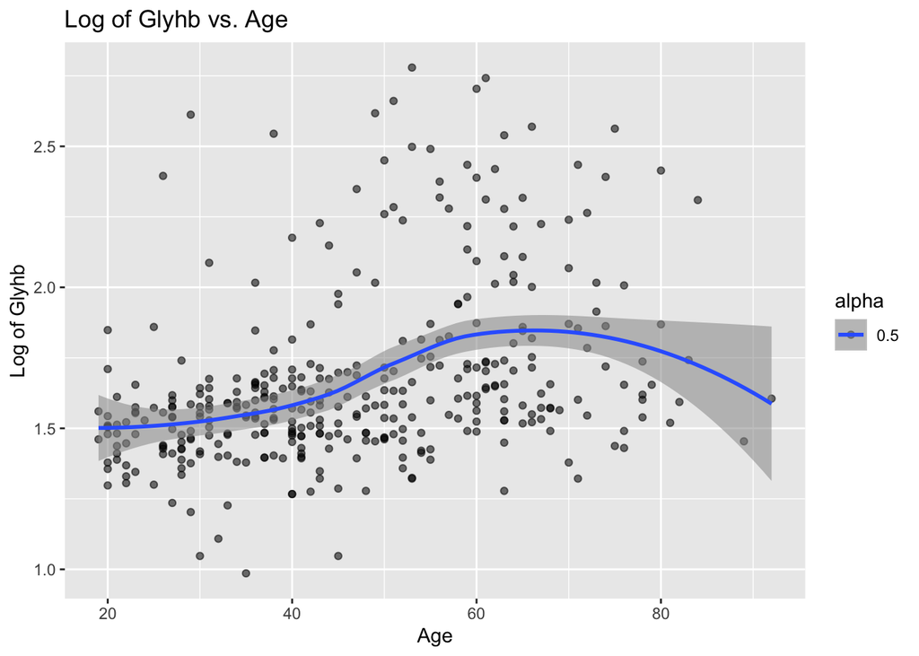

```r
ggplot(diabetes_clean,aes(y=glyhb_star,x=age,alpha=0.5)) + geom_point() + geom_smooth()+ labs(title = 'Log of Glyhb vs. Age',
                                                                                 x='Age',
                                                                                 y='Log of Glyhb')
```

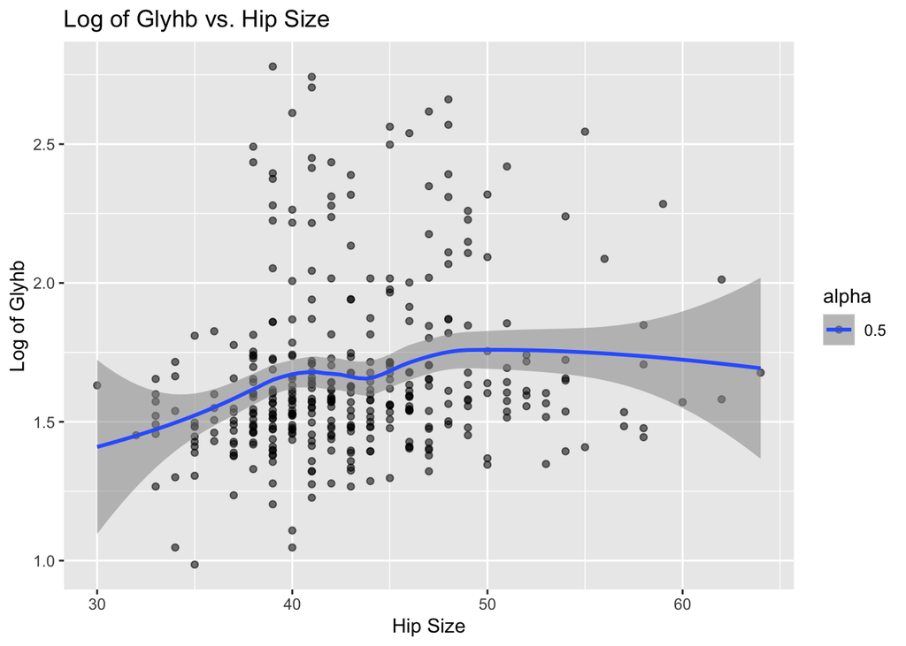

```r
ggplot(diabetes_clean,aes(y=glyhb_star,x=hip,alpha=0.5)) + geom_point() + geom_smooth()+ labs(title = 'Log of Glyhb vs. Hip Size',
                                                                                 x='Hip Size',
                                                                                 y='Log of Glyhb')
```

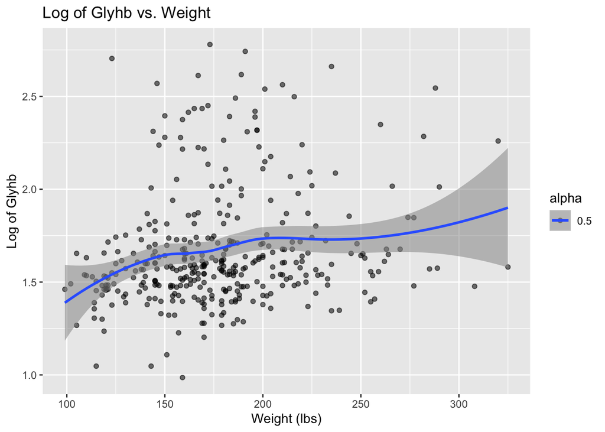

```r
ggplot(diabetes_clean,aes(y=glyhb_star,x=weight,alpha=0.5)) + geom_point() + geom_smooth()+ labs(title = 'Log of Glyhb vs. Weight',
                                                                                 x='Weight (lbs)',
                                                                                 y='Log of Glyhb')
```

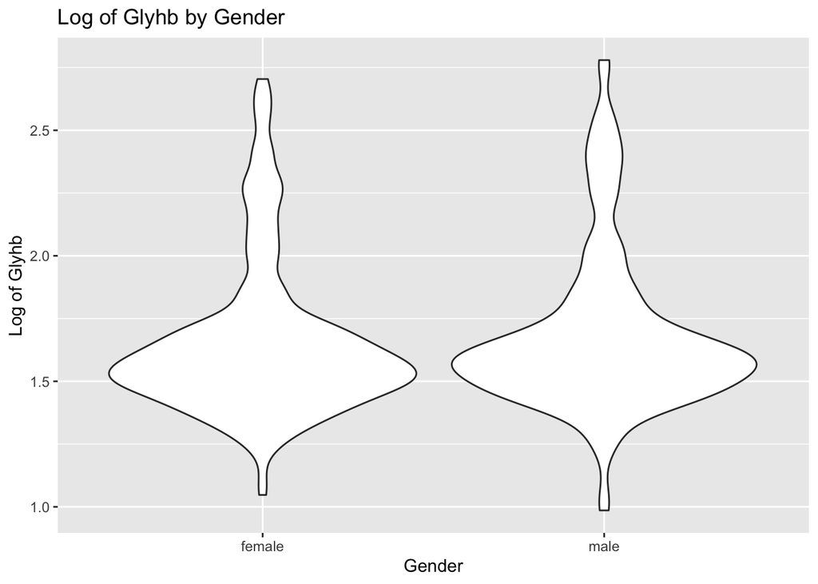

```r
ggplot(diabetes_clean,aes(y=glyhb_star,x=gender)) + geom_violin(scale="area") +  labs(title = 'Log of Glyhb by Gender',x='Gender',y='Log of Glyhb')
```

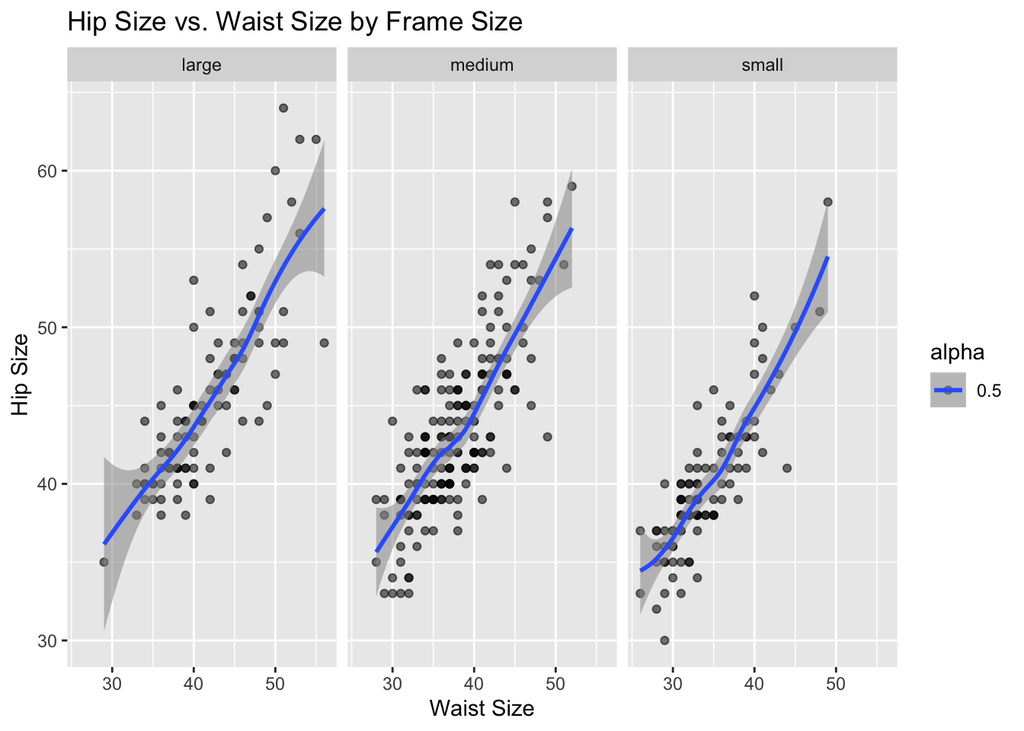

```r
#1 added a geom_smooth to see the trends easily
ggplot(diabetes_clean,aes(y=hip,x=waist,alpha=0.5)) + geom_point() + geom_smooth() + facet_wrap(~frame) + labs(title="Hip Size vs. Waist Size by Frame Size", x= 'Waist Size', y='Hip Size')
```

[figure not shown]

```r
#2 made a hex chart to make it easy too see the values easily.
ggplot(diabetes_clean,aes(y=hip,x=waist)) + geom_hex() + facet_wrap(~frame) + labs(title="Hip Size vs. Waist Size by Frame Size", x= 'Waist Size', y='Hip Size')
```

Messy Data

13.The spread function is used to spread pairs across the columns, and the gather function takes the multiple columns and makes it into pairs.

14.Both the functions gather and spread are complimentary functions, as they do they opposite tasks.

### Regression Models

```r
fit = lm(glyhb_star ~stab.glu + age + waist + ratio+ factor(frame),data=diabetes_clean)
 summary(fit)
```

```
##
## Call:
## lm(formula = glyhb_star ~ stab.glu + age + waist + ratio + factor(frame),
##     data = diabetes_clean)
##
## Residuals:
##     Min      1Q  Median      3Q     Max
## -1.0548 -0.1176 -0.0123  0.1020  1.0613
##
## Coefficients:
##                      Estimate Std. Error t value Pr(>|t|)
## (Intercept)         0.8330897  0.0984743   8.460 6.86e-16 ***
## stab.glu            0.0035182  0.0002200  15.992  < 2e-16 ***
## age                 0.0033632  0.0007144   4.708 3.58e-06 ***
## waist               0.0047925  0.0022352   2.144  0.03270 *
## ratio               0.0219341  0.0068169   3.218  0.00141 **
## factor(frame)medium 0.0309167  0.0283657   1.090  0.27648
## factor(frame)small  0.0131840  0.0351518   0.375  0.70784
## ---
## Signif. codes:  0 '***' 0.001 '**' 0.01 '*' 0.05 '.' 0.1 ' ' 1
##
## Residual standard error: 0.2085 on 359 degrees of freedom
## Multiple R-squared:  0.5643, Adjusted R-squared:  0.557
## F-statistic: 77.49 on 6 and 359 DF,  p-value: < 2.2e-16
```

The F-test statistic is 77.49 with a p-value of <.001 tells us that the model is useful for predicting Glycosolated Hemoglobin with the combination of the input variables. Also the R-square adjusted is .557 which is 55.7% of the variability. Since the last two variable doesnt help predicting Glycosolated Hemoglobin we can remove that!

```r
fit$fitted.values
```

[output not shown]

[output cut: 37 more lines]

[output not shown]

```r
# this is the estimated fitted values when the linear model "fit" is used
answer = 0.0035182*90 + 0.0033632*35 + 0.0047925*30 + 0.0219341*5.1 + 0.0131840 + 0.8330897
print(answer)
```

```
## [1] 1.536263
```

```r
#1.536263 is the estimated mean value of glyhb_star for a person
```

18. inference is is using a model learn and look at the forms and trends in a data. Prediction is using the model to find an estimate the outputs from the model.
19. linear regression is useful when the variables are linear, but it wont work in all cases since most of the real lofe datas are not linear. KNN is useful for multiple regression or non linear regression, but it needs an accurate K value.

###Reflection

20. Taking many data science and statistics class has definitely improved my knowledge in data science and with regression, plotting and visualizng. Data science is huge in today’s world there is data every where and there is a lot of good things that can be done with the data. Learning R has definitely improve my knowledge in the data science field and using ggplot makes things more eaier. I have definitely learned a lot in this class that can help me in the future.